# Origine de l'Ansatz

[Ansatz](https://medium.com/arnaldo-gunzi-quantum/what-is-ansatz-31e682b0518b) est un terme allemand, il désigne un procédé, une méthode de résolution hypothétique d'un problème. Il vise à cloisonner un problème entre des bornes plus ou moins réductrices.

Il est générique et se trouve dans un tas de domaines, comme dans la mécanique des fluides ou l'optimisation d'algorithmes.

Mais il est surtout utilisé en IA et en mécanique quantique pour l'optimisation et la résolution de problèmes complexes.

Dans notre cas, on peut conjecturer un problème comme une équation, et cela nous amène à une stratégie pour élaborer des circuits complexes.

L'Ansatz est un terme qui cache un véritable univers de réflexion en physique quantique. Il existe [plusieurs déclinaisons](https://quantaggle.com/algorithms/ansatz/) qui visent à améliorer les performances et résoudre des problèmes...

# l'Ansatz simple

C'est une déclinaison qui met en avant les fondamentaux de la réflexion sur les ansatz.

En mécanique quantique, l'ansatz régit la configuration d'un algorithme quantique en fonction de sa capacité à réduire la complexité de la solution. Dans notre cas, l'optimisation de la résolution dans les circuits multiqubit repose généralement sur le principe d'intrication, qui peut être plus ou moins importante selon les circuits. Pour le cas de l'ansatz simple, comme vous l'aurez compris, l'intrication reste simple.

On a vu plein de portes d'intrication, mais on va en garder qu'une pour nos tests afin de faire les liaisons : la porte CNOT.

L'Anstaz simple c'est simplement une liaison CNOT entre tous les qubits du circuit quantique.

Regardons un circuit que nous avons déjà construit dans la section des modèles multi-qubits.

```
--- Circuit ---
|0⟩—[L(0j,—0j,—0j,—0j)]——⊕——[L(0j,—0j,—0j,—0j)]—————————> M
|1⟩—[L(0j,—0j,—0j,—0j)]——⬤——[L(0j,—0j,—0j,—0j)]——⊕——> M
|2⟩—[L(0j,—0j,—0j,—0j)]—————————[L(0j,—0j,—0j,—0j)]——⬤——> M
```

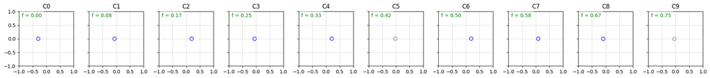

```python
from  source.quantum_model import *

circuit_A = """
L(v,v,v,x)-CX#1-L(v,v,v,x)-I
L(v,v,v,x)-CX#2-L(v,v,v,x)-CX#1
L(v,v,v,x)-I-L(v,v,v,x)-CX#2
"""

gamma = 1

Qm_intrique = quantum_model(circuit_A, gamma)

display_coefficients_fourier(Qm_intrique,10)
```

On a une bonne expressivité, et maintenant, regardons son implémentation sans inclure ces points d'intrication.

```
--- Circuit ---
|0⟩—[L(0j,—0j,—0j,—0j)]—[L(0j,—0j,—0j,—0j)]—> M
|1⟩—[L(0j,—0j,—0j,—0j)]—[L(0j,—0j,—0j,—0j)]—> M
|2⟩—[L(0j,—0j,—0j,—0j)]—[L(0j,—0j,—0j,—0j)]—> M
```

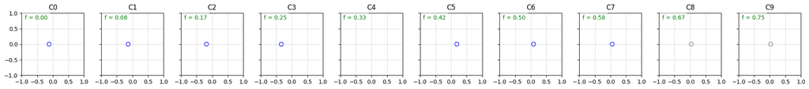

```python
circuit_B = """
L(v,v,v,x)-L(v,v,v,x)
L(v,v,v,x)-L(v,v,v,x)
L(v,v,v,x)-L(v,v,v,x)
"""

Qm_non_intrique = quantum_model(circuit_B, gamma)

display_coefficients_fourier(Qm_non_intrique,10)
```

On voit que, quand on retire l'intrication simple, la capacité d'expression du modèle multi-qubit se réduit d'un point, ce qui met en évidence l'expressivité des modèles multi-qubits intriqué , qui est supérieure au modèle multi-qubit simple.

Mais regardons leurs approximations pour donner un exemple concret.

```
--- Circuit ---
|0⟩—[L(0j,—0j,—0j,—0j)]——⊕——[L(0j,—0j,—0j,—0j)]—————————> M
|1⟩—[L(0j,—0j,—0j,—0j)]——⬤——[L(0j,—0j,—0j,—0j)]——⊕——> M
|2⟩—[L(0j,—0j,—0j,—0j)]—————————[L(0j,—0j,—0j,—0j)]——⬤——> M

Step 1: Loss = 0.096103
Step 2: Loss = 0.046231
Step 3: Loss = 0.023049
Step 4: Loss = 0.014861
Step 5: Loss = 0.026673
Step 6: Loss = 0.016633
Step 7: Loss = 0.021058
Step 8: Loss = 0.023024
Step 9: Loss = 0.022411
Step 10: Loss = 0.026894
Step 11: Loss = 0.016016
Step 12: Loss = 0.008947
Step 13: Loss = 0.007147
Step 14: Loss = 0.005180
Step 15: Loss = 0.006271
Step 16: Loss = 0.008166
Step 17: Loss = 0.007353
Step 18: Loss = 0.007275
Step 19: Loss = 0.006120
Step 20: Loss = 0.008019
Step 21: Loss = 0.008820
Step 22: Loss = 0.007727
Step 23: Loss = 0.007161
Step 24: Loss = 0.005980
Step 25: Loss = 0.005848
Step 26: Loss = 0.005731
Step 27: Loss = 0.006863
Step 28: Loss = 0.003262
Step 29: Loss = 0.003887
Step 30: Loss = 0.003253
Step 31: Loss = 0.004447
Step 32: Loss = 0.005373
Step 33: Loss = 0.003032
Step 34: Loss = 0.004800
Step 35: Loss = 0.004529
```

[output cut: 50 more lines]

```
Step 86: Loss = 0.000167
Step 87: Loss = 0.000142
Step 88: Loss = 0.000157
Step 89: Loss = 0.000043
Step 90: Loss = 0.000128
Step 91: Loss = 0.000181
Step 92: Loss = 0.000113
Step 93: Loss = 0.000086
Step 94: Loss = 0.000086
Step 95: Loss = 0.000088
Step 96: Loss = 0.000086
Step 97: Loss = 0.000083
Step 98: Loss = 0.000141
Step 99: Loss = 0.000078
Step 100: Loss = 0.000067
```

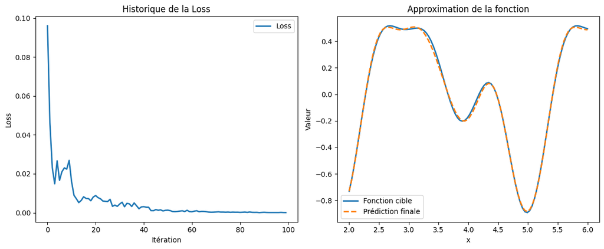

```python
from source.function import *

approximate(
    sinusoidale_complexe_2,
    circuit_A,
    linespace = (2,6),
    number_points = 100,
    gamma = 2,
    steps = 100,
    learning_rate = 0.3,
    plot = False
)
```

```
--- Circuit ---
|0⟩—[L(0j,—0j,—0j,—0j)]—[L(0j,—0j,—0j,—0j)]—> M
|1⟩—[L(0j,—0j,—0j,—0j)]—[L(0j,—0j,—0j,—0j)]—> M
|2⟩—[L(0j,—0j,—0j,—0j)]—[L(0j,—0j,—0j,—0j)]—> M

Step 1: Loss = 1.114246
Step 2: Loss = 0.585540
Step 3: Loss = 0.283044
Step 4: Loss = 0.071196
Step 5: Loss = 0.400924
Step 6: Loss = 0.223659
Step 7: Loss = 0.101120
Step 8: Loss = 0.281236
Step 9: Loss = 0.314690
Step 10: Loss = 0.139204
Step 11: Loss = 0.119041
Step 12: Loss = 0.108809
Step 13: Loss = 0.109179
Step 14: Loss = 0.044548
Step 15: Loss = 0.059592
Step 16: Loss = 0.117472
Step 17: Loss = 0.099076
Step 18: Loss = 0.073946
Step 19: Loss = 0.052606
Step 20: Loss = 0.034702
Step 21: Loss = 0.015495
Step 22: Loss = 0.018005
Step 23: Loss = 0.031576
Step 24: Loss = 0.046039
Step 25: Loss = 0.053731
Step 26: Loss = 0.031280
Step 27: Loss = 0.042196
Step 28: Loss = 0.023505
Step 29: Loss = 0.038890
Step 30: Loss = 0.028486
Step 31: Loss = 0.017533
Step 32: Loss = 0.010655
Step 33: Loss = 0.011343
Step 34: Loss = 0.029386
Step 35: Loss = 0.018143
```

[output cut: 50 more lines]

```
Step 86: Loss = 0.011155
Step 87: Loss = 0.013914
Step 88: Loss = 0.010229
Step 89: Loss = 0.011600
Step 90: Loss = 0.009846
Step 91: Loss = 0.011812
Step 92: Loss = 0.010192
Step 93: Loss = 0.010624
Step 94: Loss = 0.011874
Step 95: Loss = 0.010117
Step 96: Loss = 0.012443
Step 97: Loss = 0.015296
Step 98: Loss = 0.010396
Step 99: Loss = 0.011185
Step 100: Loss = 0.010553
```

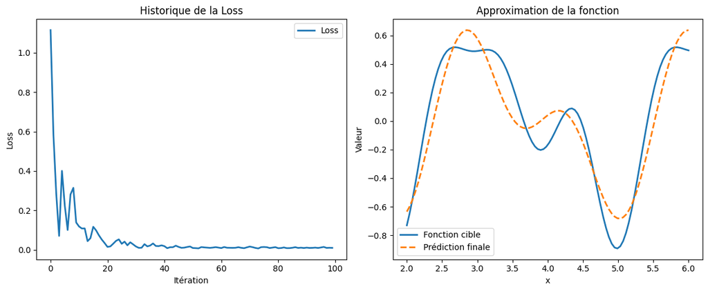

```python
approximate(
    sinusoidale_complexe_2,
    circuit_B,
    linespace = (2,6),
    number_points = 100,
    gamma = 2,
    steps = 100,
    learning_rate = 0.3,
    plot = False
)
```

Par ces résultats, on peut effectivement constater la différence d’expressivité des modèles sur une sinusoïdale complexe : l’entrelacement entre les qubits permet de comprendre cette complexité avec une convergence plus rapide et plus complexe des fonctions dans notre cas.

# l'Ansatz complexe

Pour l’ansatz complexe, la définition est triviale : on connecte tous les qubits entre eux une seule fois. C’est une intrication globale sur l’ensemble des qubits. Cette stratégie est aussi appelée [fully-connected](https://link.springer.com/article/10.1007/s11467-023-1269-3).

Voilà l’expressivité de ce nouveau modèle sur trois qubits :

```
--- Circuit ---
|0⟩—[L(0j,—0j,—0j,—0j)]——⊕——[L(0j,—0j,—0j,—0j)]—————————[L(0j,—0j,—0j,—0j)]——⬤——> M
|1⟩—[L(0j,—0j,—0j,—0j)]——⬤——[L(0j,—0j,—0j,—0j)]——⊕——[L(0j,—0j,—0j,—0j)]—————————> M
|2⟩—————————————————————————————[L(0j,—0j,—0j,—0j)]——⬤——[L(0j,—0j,—0j,—0j)]——⊕——> M
```

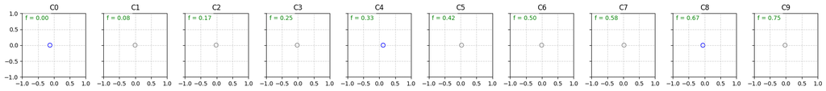

```python
circuit_C = """
L(v,v,v,x)-CX#1-L(v,v,v,x)-I   -L(v,v,v,x)-CX#2
L(v,v,v,x)-CX#2-L(v,v,v,x)-CX#1-L(v,v,v,x)-I
I         -I   -L(v,v,v,x)-CX#2-L(v,v,v,x)-CX#1
"""

gamma = 1

Qm_intrique = quantum_model(circuit_C, gamma)

display_coefficients_fourier(Qm_intrique,10)
```

```
--- Circuit ---
|0⟩—[L(0j,—0j,—0j,—0j)]——⊕——[L(0j,—0j,—0j,—0j)]—————————[L(0j,—0j,—0j,—0j)]—————————[L(0j,—0j,—0j,—0j)]——⊕——[L(0j,—0j,—0j,—0j)]——⬤——> M
|1⟩—[L(0j,—0j,—0j,—0j)]——⬤——[L(0j,—0j,—0j,—0j)]——⊕——[L(0j,—0j,—0j,—0j)]——⬤——[L(0j,—0j,—0j,—0j)]—————————————————————————————————————> M
|2⟩—————————————————————————————[L(0j,—0j,—0j,—0j)]——⬤——[L(0j,—0j,—0j,—0j)]——⊕——[L(0j,—0j,—0j,—0j)]——⬤——[L(0j,—0j,—0j,—0j)]——⊕——> M
```

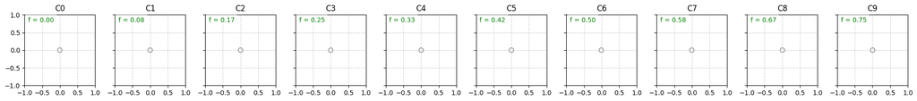

```python
circuit_D = """
L(v,v,v,x)-CX#1-L(v,v,v,x)-I   -L(v,v,v,x)-I   -L(v,v,v,x)-CX#1-L(v,v,v,x)-CX#2
L(v,v,v,x)-CX#2-L(v,v,v,x)-CX#1-L(v,v,v,x)-CX#2-L(v,v,v,x)-I   -I         -I
I         -I   -L(v,v,v,x)-CX#2-L(v,v,v,x)-CX#1-L(v,v,v,x)-CX#2-L(v,v,v,x)-CX#1
"""

gamma = 1

Qm_intrique = quantum_model(circuit_D, gamma)

display_coefficients_fourier(Qm_intrique,10)
```

Dans ces implémentations, on remarque que plus les circuits sont intriqués, plus la convergence est complexe. Bien sûr, ce n'est pas une vérité générale, mais dans cette configuration, l'augmentation des portes d'intrication n'est pas synonyme de meilleure expressivité du circuit. L'expressivité dépend donc des portes d'encodage, des portes de gestion de poids, mais aussi des liaisons d'intrication dans le circuit.

Maintenant testons sur un niveau d'approximation plus complexe :

```
--- Circuit ---
|0⟩—[L(0j,—0j,—0j,—0j)]——⊕——[L(0j,—0j,—0j,—0j)]—————————> M
|1⟩—[L(0j,—0j,—0j,—0j)]——⬤——[L(0j,—0j,—0j,—0j)]——⊕——> M
|2⟩—[L(0j,—0j,—0j,—0j)]—————————[L(0j,—0j,—0j,—0j)]——⬤——> M

Step 1: Loss = 0.072888
Step 2: Loss = 0.014954
Step 3: Loss = 0.011145
Step 4: Loss = 0.006231
Step 5: Loss = 0.016925
Step 6: Loss = 0.023460
Step 7: Loss = 0.016918
Step 8: Loss = 0.009490
Step 9: Loss = 0.013307
Step 10: Loss = 0.014106
Step 11: Loss = 0.015952
Step 12: Loss = 0.012612
Step 13: Loss = 0.004747
Step 14: Loss = 0.006700
Step 15: Loss = 0.010516
Step 16: Loss = 0.013209
Step 17: Loss = 0.007823
Step 18: Loss = 0.002108
Step 19: Loss = 0.002957
Step 20: Loss = 0.004554
Step 21: Loss = 0.004781
Step 22: Loss = 0.003238
Step 23: Loss = 0.003420
Step 24: Loss = 0.003589
Step 25: Loss = 0.002861
Step 26: Loss = 0.002319
Step 27: Loss = 0.003070
Step 28: Loss = 0.003733
Step 29: Loss = 0.003904
Step 30: Loss = 0.002646
Step 31: Loss = 0.003603
Step 32: Loss = 0.002174
Step 33: Loss = 0.002906
Step 34: Loss = 0.003350
Step 35: Loss = 0.002802
```

[output cut: 50 more lines]

```
Step 86: Loss = 0.002111
Step 87: Loss = 0.001511
Step 88: Loss = 0.001227
Step 89: Loss = 0.001800
Step 90: Loss = 0.001483
Step 91: Loss = 0.000914
Step 92: Loss = 0.001439
Step 93: Loss = 0.001585
Step 94: Loss = 0.001287
Step 95: Loss = 0.001170
Step 96: Loss = 0.001488
Step 97: Loss = 0.001547
Step 98: Loss = 0.002095
Step 99: Loss = 0.001277
Step 100: Loss = 0.000783
```

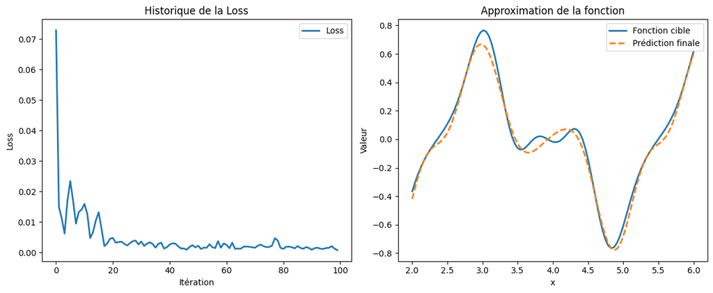

```python
approximate(
    sinusoidale_complexe_3,
    circuit_A,
    linespace = (2,6),
    number_points = 100,
    gamma = 2,
    steps = 100,
    learning_rate = 0.3,
    plot = False
)
```

```
--- Circuit ---
|0⟩—[L(0j,—0j,—0j,—0j)]——⊕——[L(0j,—0j,—0j,—0j)]—————————[L(0j,—0j,—0j,—0j)]——⬤——> M
|1⟩—[L(0j,—0j,—0j,—0j)]——⬤——[L(0j,—0j,—0j,—0j)]——⊕——[L(0j,—0j,—0j,—0j)]—————————> M
|2⟩—————————————————————————————[L(0j,—0j,—0j,—0j)]——⬤——[L(0j,—0j,—0j,—0j)]——⊕——> M

Step 1: Loss = 0.105013
Step 2: Loss = 0.074629
Step 3: Loss = 0.082886
Step 4: Loss = 0.062366
Step 5: Loss = 0.040042
Step 6: Loss = 0.055481
Step 7: Loss = 0.047627
Step 8: Loss = 0.029986
Step 9: Loss = 0.049146
Step 10: Loss = 0.059863
Step 11: Loss = 0.049380
Step 12: Loss = 0.040304
Step 13: Loss = 0.038104
Step 14: Loss = 0.023673
Step 15: Loss = 0.041345
Step 16: Loss = 0.029374
Step 17: Loss = 0.032117
Step 18: Loss = 0.031526
Step 19: Loss = 0.045919
Step 20: Loss = 0.036331
Step 21: Loss = 0.033032
Step 22: Loss = 0.042047
Step 23: Loss = 0.030236
Step 24: Loss = 0.023721
Step 25: Loss = 0.023404
Step 26: Loss = 0.030114
Step 27: Loss = 0.037670
Step 28: Loss = 0.026675
Step 29: Loss = 0.030837
Step 30: Loss = 0.037302
Step 31: Loss = 0.035266
Step 32: Loss = 0.020309
Step 33: Loss = 0.027512
Step 34: Loss = 0.020830
Step 35: Loss = 0.019624
```

[output cut: 50 more lines]

```
Step 86: Loss = 0.026530
Step 87: Loss = 0.023153
Step 88: Loss = 0.022917
Step 89: Loss = 0.026531
Step 90: Loss = 0.015738
Step 91: Loss = 0.025735
Step 92: Loss = 0.022088
Step 93: Loss = 0.024383
Step 94: Loss = 0.008117
Step 95: Loss = 0.016348
Step 96: Loss = 0.014830
Step 97: Loss = 0.013982
Step 98: Loss = 0.019632
Step 99: Loss = 0.029921
Step 100: Loss = 0.023230
```

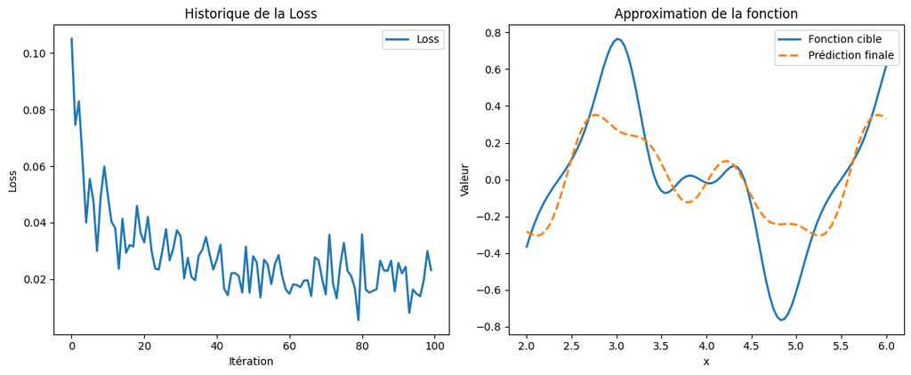

```python
approximate(
    sinusoidale_complexe_3,
    circuit_C,
    linespace = (2,6),
    number_points = 100,
    gamma = 2,
    steps = 100,
    learning_rate = 0.3,
    plot = False
)
```

Comme on peut le constater avec ces approximations, les résultats du circuit A sont plus performants que ceux du circuit C, qui lui est largement plus intriqué. Mais, comme dit auparavant, dans certains cas, une intrication trop forte rend difficile l'exploitation des données dans le système quantique.